# Visualisation of Inflammatory Caspase Substrate sites

Ryan Knight

13/04/2021

# 1 Introduction

**Caspases** (**c**ysteine **asp**art**ases**), are a family of proteases that carry out essential roles in forms of programmed cell death.

Cellular stress and infection promote the assembly of inflammasome complexes, leading to the activation of inflammatory caspases. Activation of these inflammatory caspases, Caspase-1, Caspase-4 and Caspase-5 in humans, and Caspase-1 and Caspase-11 in mice, induces a morphologically distinct form of programmed cell death known as pyroptosis. When undergoing pyroptosis, cells rupture and release their contents, including pro-inflammatory cytokines and danger signals to both prevent intracellular pathogen replication and induce an immune response.

Despite their namesake, there exists substantive evidence that caspases do not exclusively cleave substrates at aspartate residues but have a propensity to act at a variety of other amino acid residues (Seaman et al. 2016), most notably glutamate, possessing similar acidic properties to aspartate.

For previous work we compiled a database of inflammatory caspase substrates (unpublished data). As appreciation is developing for the more nuanced nature of caspase cleavage site consensus sequences, this report aims to provide a reproducible analysis and visualisation of features of caspase cleavage sites using R 4.0 (R Core Team 2020).

# 2 Methods and Results

## 2.1 Visualisation of consensus sequence characteristics

The acquired database of inflammatory caspase substrates was tidied into an amenable format (Wickham et al. 2019), and cleavage site consensus interpreted with ggseqlogo (Wagih 2017).

Amino acids were categorised by chemical properties- acidity/basicity, hydrophobicity/polarity, and visualised in four plots: all 177 inflammatory caspase substrates, 113 human Caspase-1 substrates, 30 murine Caspase-1 substrates and 31 human Caspase-4 substrates. Human Caspase-5 and murine Caspase-11 substrate consensus is not presented as few substrates have been recorded in the data set.

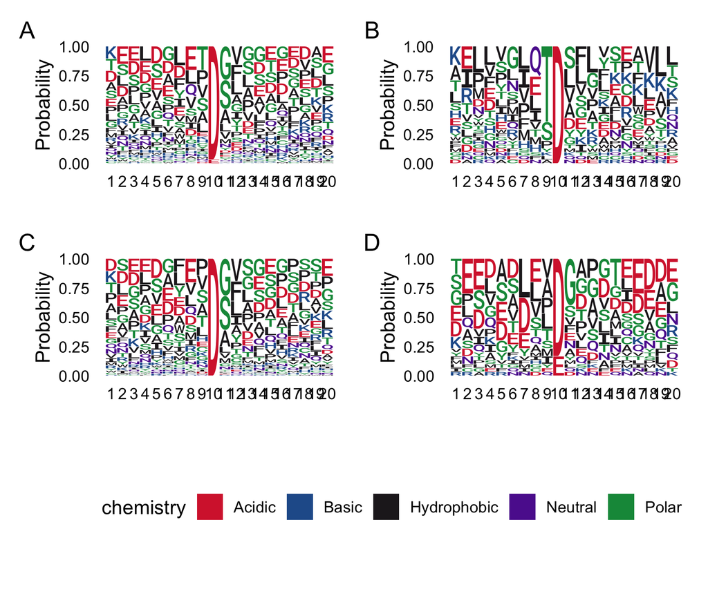

Figure 2.1: Visualisation of inflammatory Caspase cleavage sites consensus categorised by chemistry, and position 10-11 represents the site of cleavage. A: all Caspases (177 sites), B: Caspase-4 (31), C: human Caspase-1 (113), D: murine Caspase-1 (30).

Visualisations shown in Figure 2.1 demonstrate the lack of an apparent pattern in the consensus sequence, with the exception of an aspartate (**D**), or minorly glutamate (**E**), residue at the cleavage site at position 10.

It should be noted that the studies comprising this data set did observe some sites with other residues in this position, though they were deliberately excluded from the compiled data set as there is insufficient experimental evidence for cleavage at sites other than **D** and **E**. These observations could reasonably be due to experimental artefacts such as contamination with other proteases (ie. cathepsins)

Regardless, the observed results diverge greatly from the traditional dogma of DEVD cleavage sites for caspases that would lie at P7-P10 in Figure 2.1. Site chemistry also follows no overwhelming pattern, nor does a hydrophobicity scale of human Caspase-1 and Caspase 4 substrates (Figure 2.2).

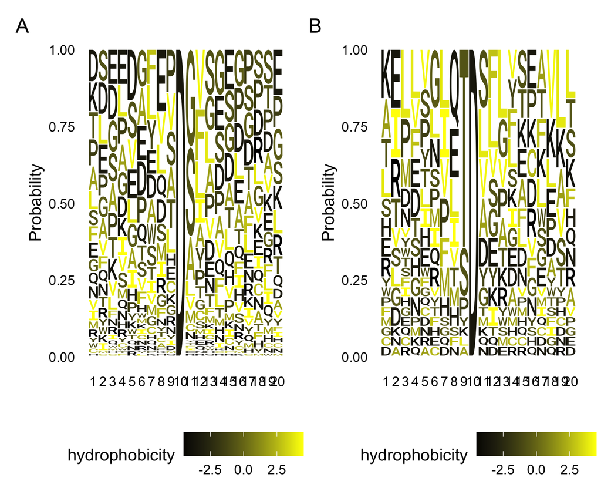

Figure 2.2: Representation of sequence consensus accross human caspase substrates, coloured by relative hydrophobicity. A) 113 human Caspase-1 cleavage sites, 31 Caspase-4 cleavage sites.

Rationally, there is a factor other than identity of local primary sequence chemistry explaining the identification of cleavage sites by inflammatory caspases, such as higher-order patterns within primary sequence, secondary and tertiary structure, or post-translational modification.

Visualisation of the consistency of substrate P4-P1 residues between model species does (Figure 2.3) shows a high degree of conservation.

This suggests that the amino acid residues surrounding the cleavage site are important, despite the general inconsistency of their chemistry (Figure 2.1). Post-translational modifications present an interesting candidate for investigation alongside patterns within primary sequence, which will be followed through machine learning methods.

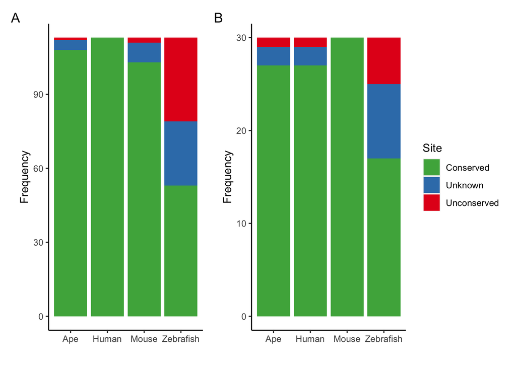

Figure 2.3: Simple representation of assessment of substrate P4-P1 conservation in model organsisms (Ape = *P. troglodytes*, Human = *H. sapiens*, Mouse = *M. musculus*, Zebrafish = *D. rerio*. A) 113 sites cleaved by human Caspase-1. B) 30 sites cleaved by murine Caspase-1. Note that the orthologues have not necessarily been determined as substrates for their species’ corresponding caspase; the conservation of the substrate is in focus, not the mechanism.

## 2.2 Phosphate site analysis

Data was tidied into an amenable format for analysis with a modified version of phosphate site prediction model, DeepPhos, which was assesed to be capable of identification of previously unknown phosphate sites (Luo et al. 2019). 146 human inflammatory Caspase substrates were processed using the DeepPhos prediction model against a threshold score of **0.5** (measured between 0 and 1). Results were categorised by position in the sequence and represented in Figure 2.4.

Position 10 represents the cleavage site (**D**/**E**), explaining the lack of any predicted phosphorylation sites at this position.

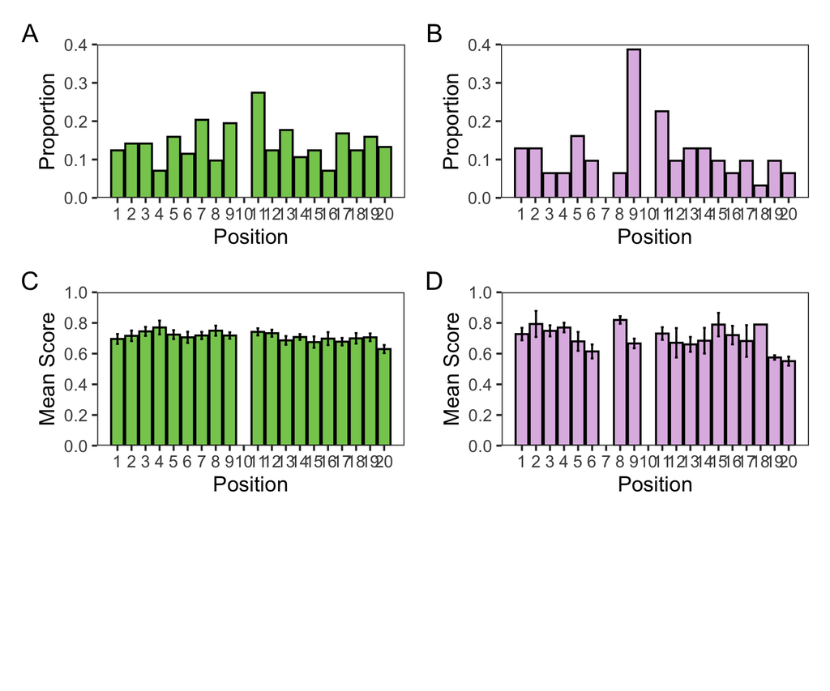

Figure 2.4: Representations of phosphorylation prediction results (score threshold 0.5) amongst human inflammatory Caspase substrates. Position 10 is the cleavage site (D/E). A) Prevelance of predicted phosphorylation sites for 113 human Caspase 1 substrates. A) Prevelance of predicted phosphorylation sites for 31 Caspase 4 substrates. C, D) Evaluation of the strength of mean phosphate prediction scores for each position. Error bars show the standard error of the mean. C) 113 human Caspase 1 substrates. D) 31 Caspase 4 substrates.

Figure 2.4 also contains a representation of relative strengths of potential phosphorylation sites between positions. Standard errors of the mean were calculated and depicted in error bars as an indication of the accuracy of computation of the mean. Overlapping standard error bars suggest that differences in strength between sites is either not, or minimally, statistically significant (though statistical testing beyond visualization would be required to evaluate this).

## 2.3 Site consensus visualised through tSNE

From simple visualisations there did not appear to be defined local consensus sequences for inflammatory caspases (Figure 2.1), but this information was not definitive. More rigorous machine-learning based visualisation was performed through the use of t-distributed stochastic neighbour embedding (t-SNE) (Figure 2.5) (Krijthe and Van der Maaten 2015).

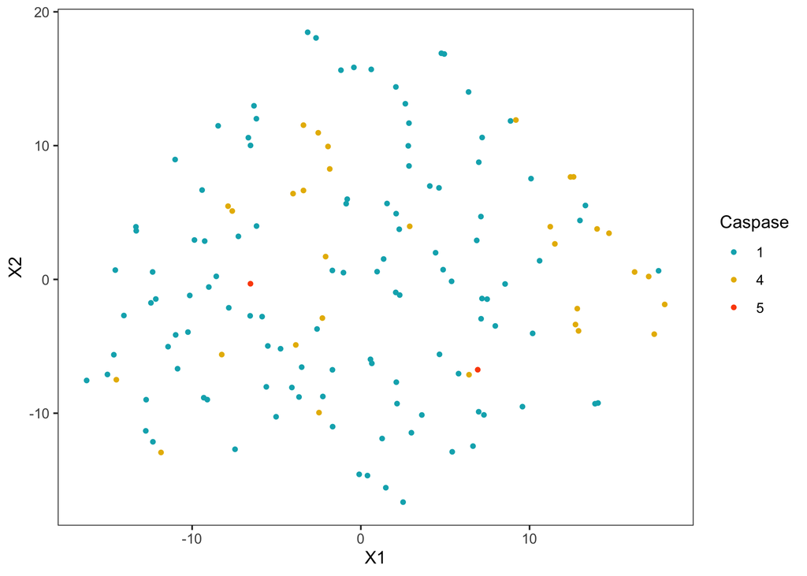

Figure 2.5: tSNE visualisation of the closest 20 amino acids to 146 human caspase cleavage sites. Site chemical character is not taken into account.

Unexpectedly, tSNE results do not demonstrate separate populations for Caspase 1 and Caspase-4 substrates.

The primary sequence of cleavage sites alone may not be sufficient to separate inflammatory caspase substrates, without taking into account amino acid chemistry and post-translational modification. Combined with the lack of an evident single consensus pattern based on amino-acid identity or chemistry (Figures 2.1 and 2.2), this suggests the existence of complex patterns in the local amino acid sequence of inflammatory caspase cleavage sites that confer their specificity.

# 3 References

Dix, Melissa M., Gabriel M. Simon, Chu Wang, Eric Okerberg, Matthew P. Patricelli, and Benjamin F. Cravatt. 2012. “Functional Interplay Between Caspase Cleavage and Phosphorylation Sculpts the Apoptotic Proteome.” *Cell* 150 (2): 426–40. https://doi.org/10.1016/j.cell.2012.05.040.

Kaplan, Jacob. 2020. *fastDummies: Fast Creation of Dummy (Binary) Columns and Rows from Categorical Variables*. https://CRAN.R-project.org/package=fastDummies.

Krijthe, Jesse H, and L Van der Maaten. 2015. “Rtsne: T-Distributed Stochastic Neighbor Embedding Using Barnes-Hut Implementation.” *R Package Version 0.13, URL Https://Github.com/Jkrijthe/Rtsne*.

Luo, Fenglin, Minghui Wang, Yu Liu, Xing-Ming Zhao, and Ao Li. 2019. “DeepPhos: Prediction of Protein Phosphorylation Sites with Deep Learning.” *Bioinformatics* 35 (16): 2766–73. https://doi.org/10.1093/bioinformatics/bty1051.

R Core Team. 2020. *R: A Language and Environment for Statistical Computing*. Vienna, Austria: R Foundation for Statistical Computing. https://www.R-project.org/.

Seaman, J E, O Julien, P S Lee, T J Rettenmaier, N D Thomsen, and J A Wells. 2016. “Cacidases: Caspases Can Cleave After Aspartate, Glutamate and Phosphoserine Residues.” *Cell Death & Differentiation* 23 (10): 1717–26. https://doi.org/10.1038/cdd.2016.62.

Wagih, Omar. 2017. “Ggseqlogo: A Versatile r Package for Drawing Sequence Logos.” *Bioinformatics* 33 (22): 3645–47. https://doi.org/10.1093/bioinformatics/btx469.

Wickham, Hadley, Mara Averick, Jennifer Bryan, Winston Chang, Lucy D’Agostino McGowan, Romain François, Garrett Grolemund, et al. 2019. “Welcome to the Tidyverse.” *Journal of Open Source Software* 4 (43): 1686. https://doi.org/10.21105/joss.01686.